# DATA 624 Homework 1 - Time Series

## Question 2.3

Download some monthly Australian retail data from the book website. These represent retail sales in various categories for different Australian states, and are stored in a MS-Excel file.

1. You can read the data into R with the following script:

```r
retaildata <- readxl::read_excel("data/retail.xlsx", skip=1)
```

The second argument (skip=1) is required because the Excel sheet has two header rows.

2. Select one of the time series as follows (but replace the column name with your own chosen column):

```r
myts <- ts(retaildata[,"A3349873A"],
  frequency=12, start=c(1982,4))
```

3. Explore your chosen retail time series using the following functions:

autoplot(), ggseasonplot(), ggsubseriesplot(), gglagplot(), ggAcf()

Can you spot any seasonality, cyclicity and trend? What do you learn about the series?

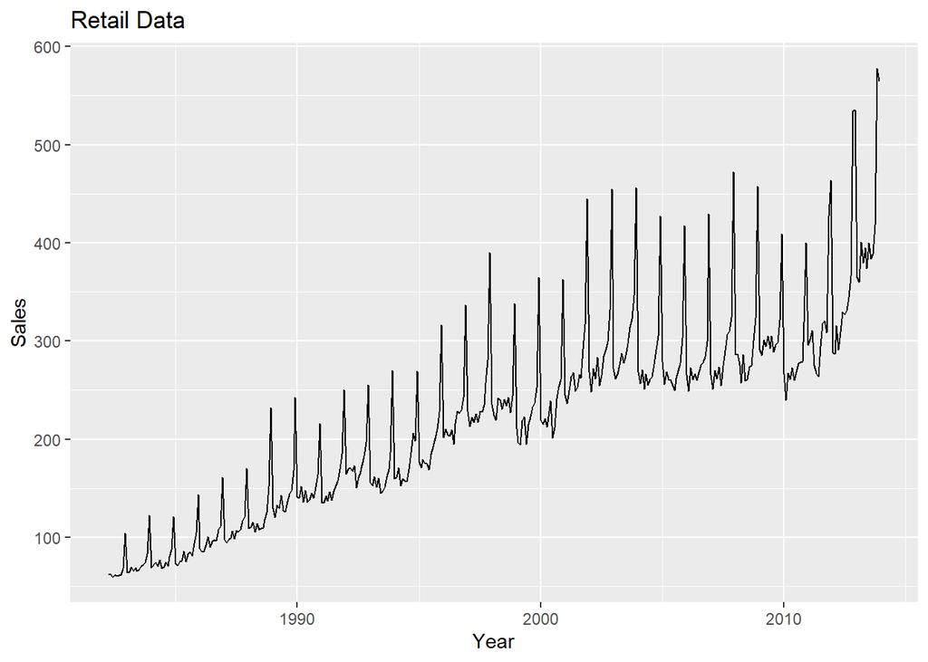

```r
autoplot(myts) +
  ggtitle('Retail Data') +
  xlab('Year') +
  ylab('Sales')
```

**There seems to be a pattern here. The overall trend is up year over year. The volatility seem to increase year over year. The sales seems seasonal i.e goes up in the end of the year and then comes down. This pattern appears to be happening every year. The sales seem to have coorelation to year end holidays**

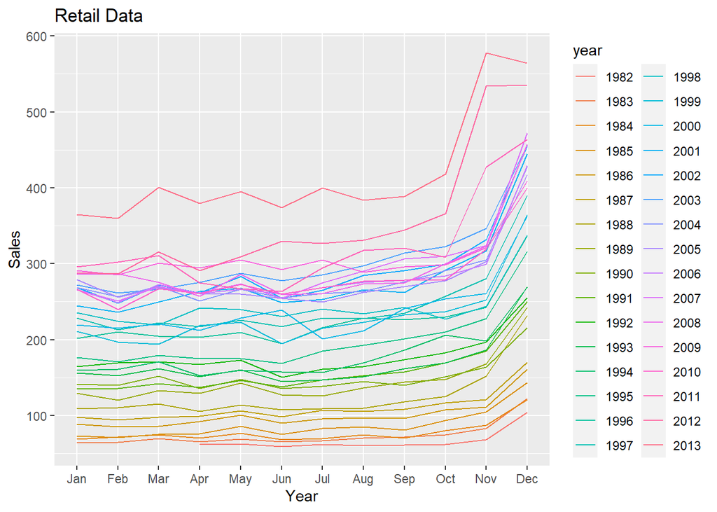

```r
ggseasonplot(myts) +
  ggtitle('Retail Data') +
  xlab('Year') +
  ylab('Sales')
```

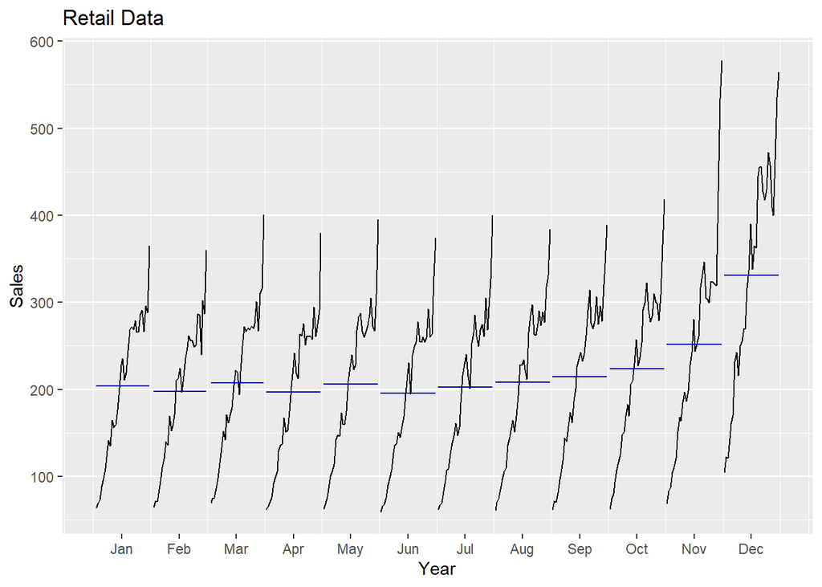

```r
ggsubseriesplot(myts) +
  ggtitle('Retail Data') +
  xlab('Year') +
  ylab('Sales')
```

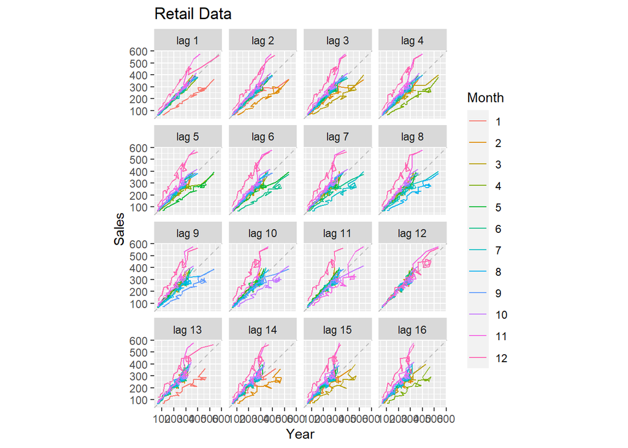

```r
gglagplot(myts) +
  ggtitle('Retail Data') +
  xlab('Year') +
  ylab('Sales')
```

**There is positive trend in the time series**

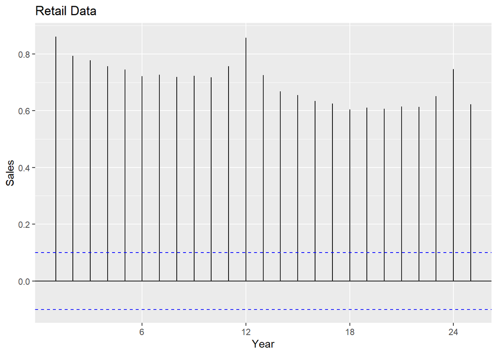

```r
ggAcf(myts) +
  ggtitle('Retail Data') +
  xlab('Year') +
  ylab('Sales')
```

**The ACF chart shows us the trend. Every year there is a U shaped pattern.**

## Question 2.6

Use the following graphics functions: autoplot(), ggseasonplot(), ggsubseriesplot(), gglagplot(), ggAcf() and explore features from the following time series: hsales, usdeaths, bricksq, sunspotarea, gasoline.

Can you spot any seasonality, cyclicity and trend? What do you learn about the series?

```r
analyzets = function(ts, plottitle)
{
  print(autoplot(ts) + ggtitle(plottitle))
  try(print(ggseasonplot(ts) + ggtitle(plottitle)))
  try(print(ggsubseriesplot(ts) + ggtitle(plottitle)))
  print(gglagplot(ts) + ggtitle(plottitle))
  print(ggAcf(ts) + ggtitle(plottitle))
}
```

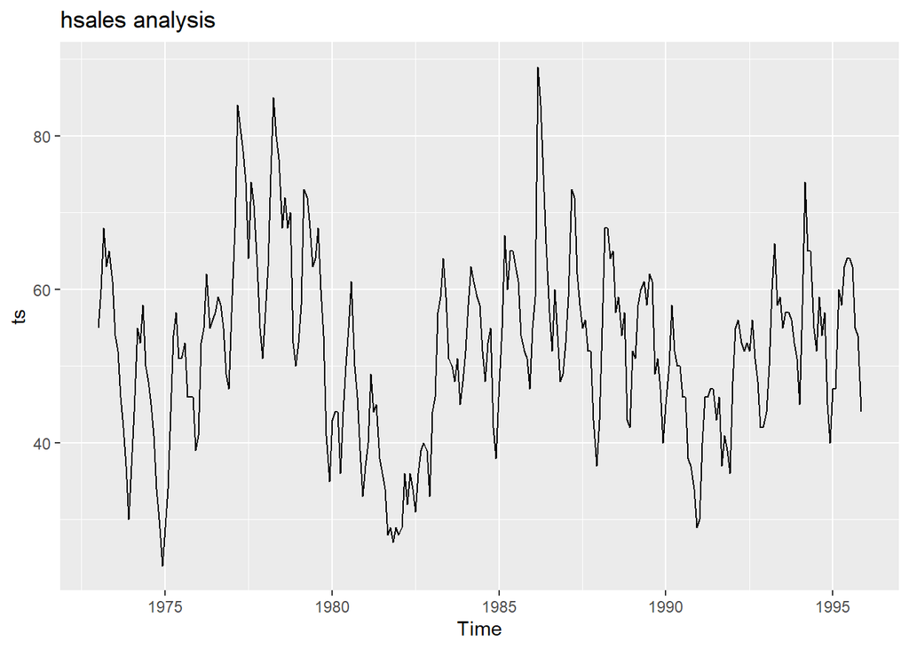

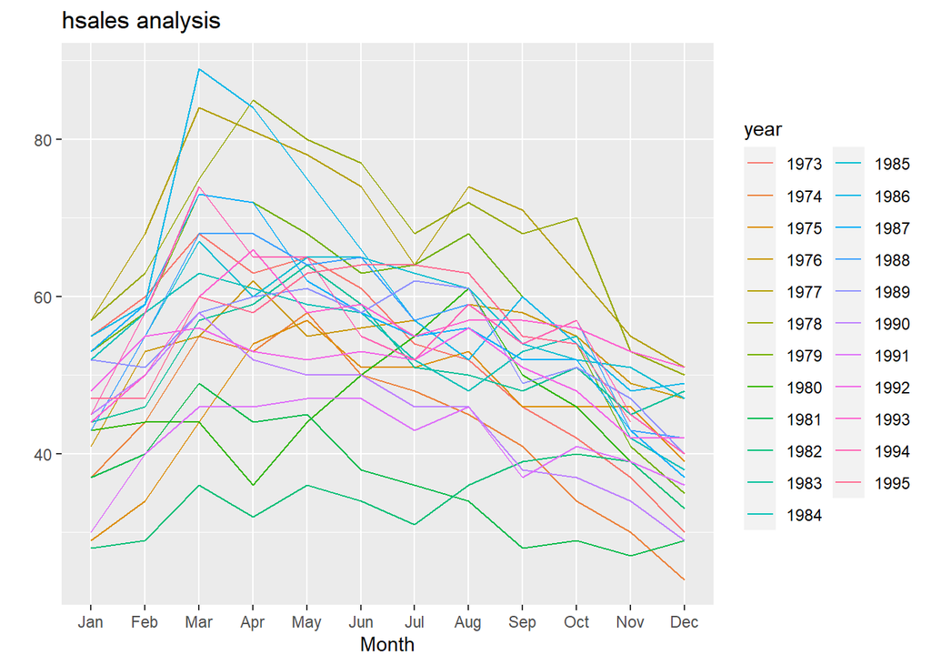

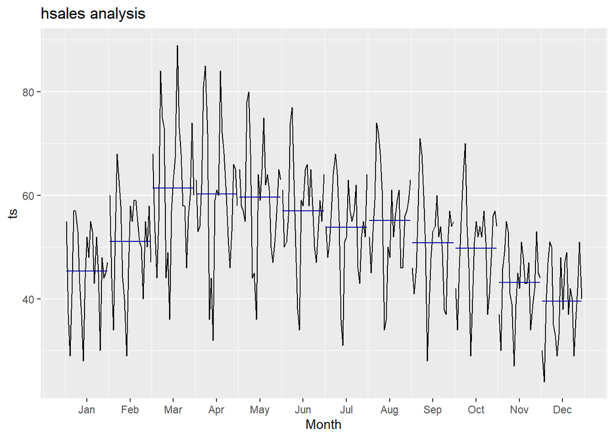

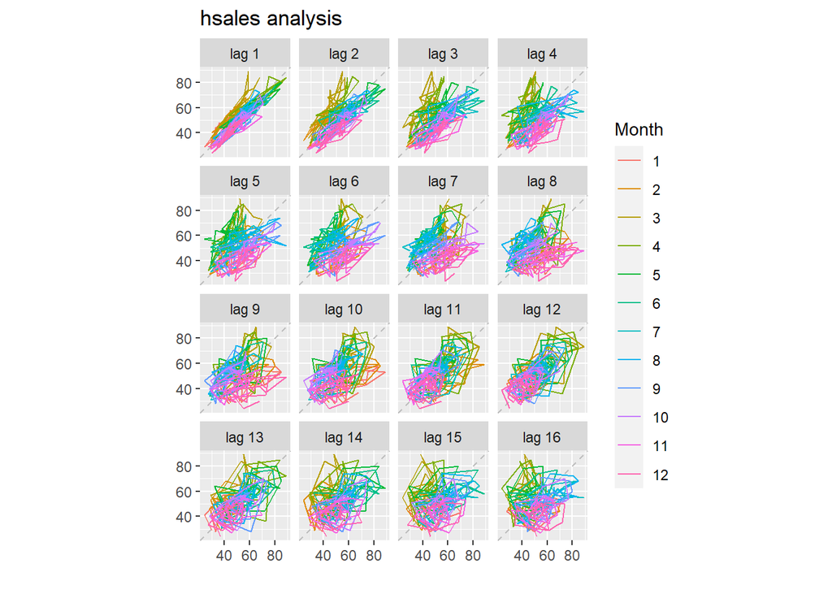

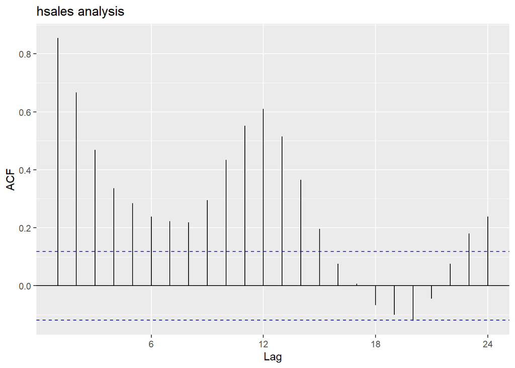

```r
analyzets(hsales, "hsales analysis")
```

**The data seems to peak in march. From the chart we can see seasonal pattern in the time series**

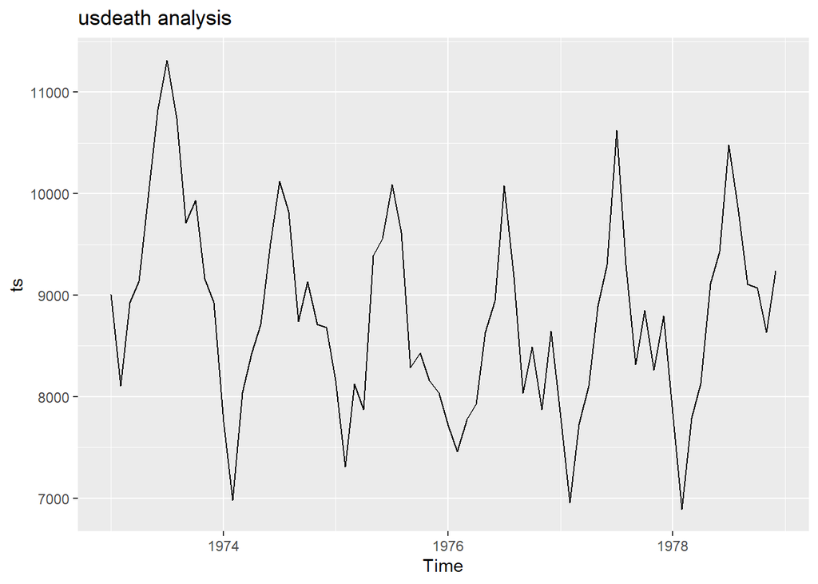

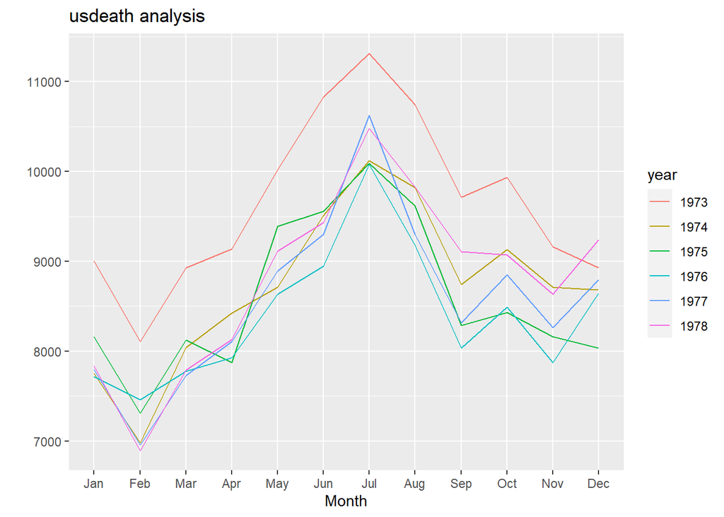

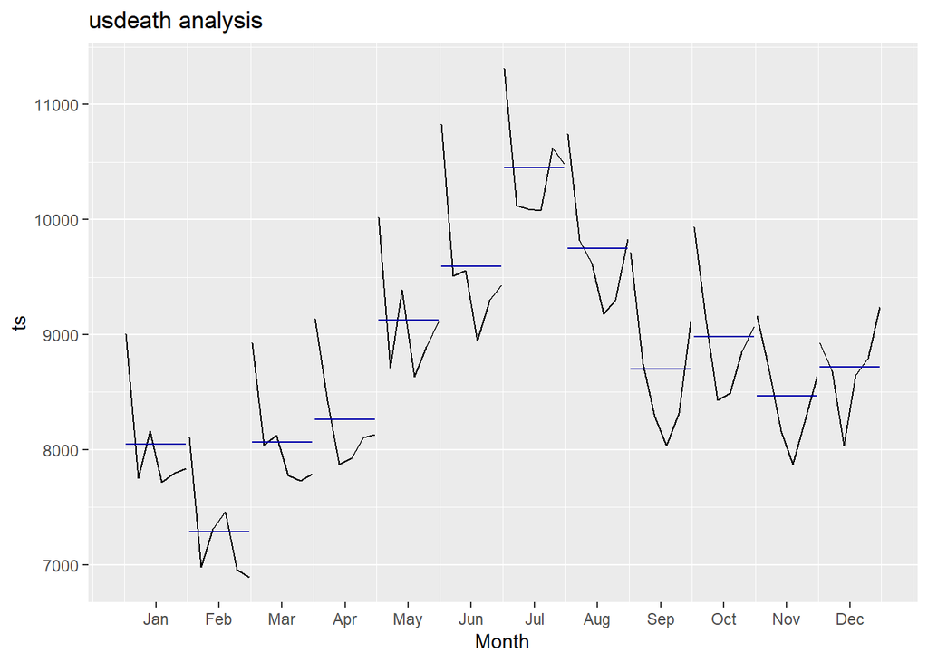

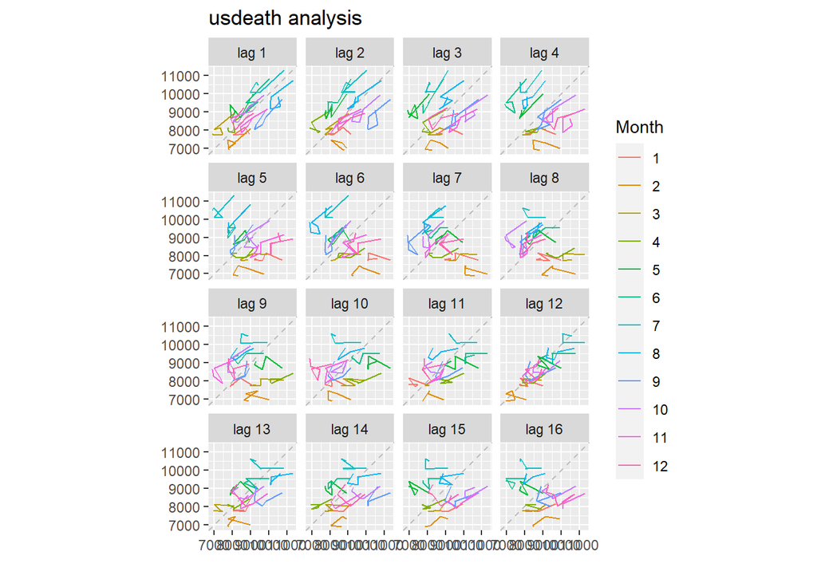

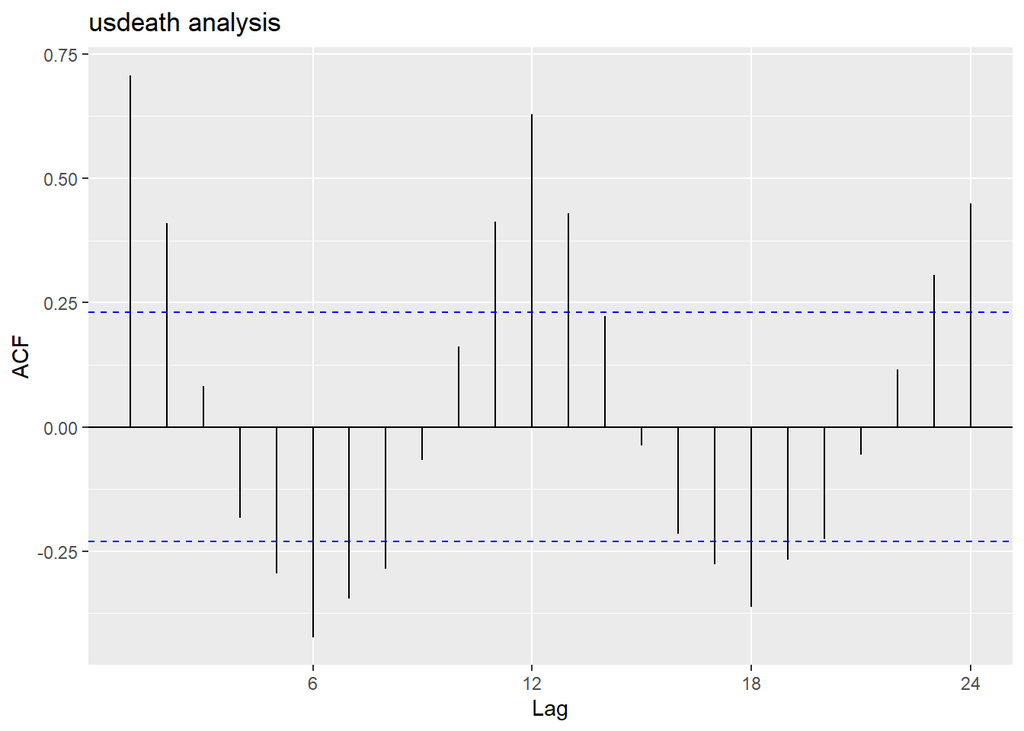

```r
analyzets(usdeaths, "usdeath analysis")
```

**We see a year over year pattern. The data seem to have a consistent pattern. There is a peak in June-July. The lags chart shows mixed bag of correlation. This chart shows seasonality presence in the time series**

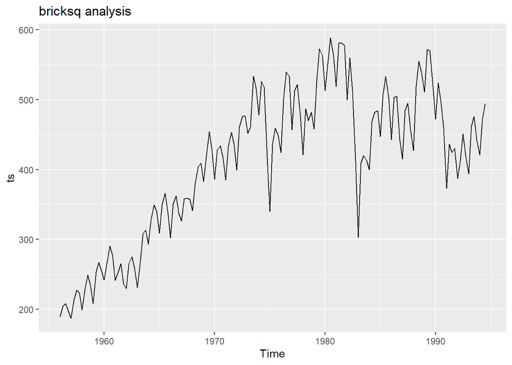

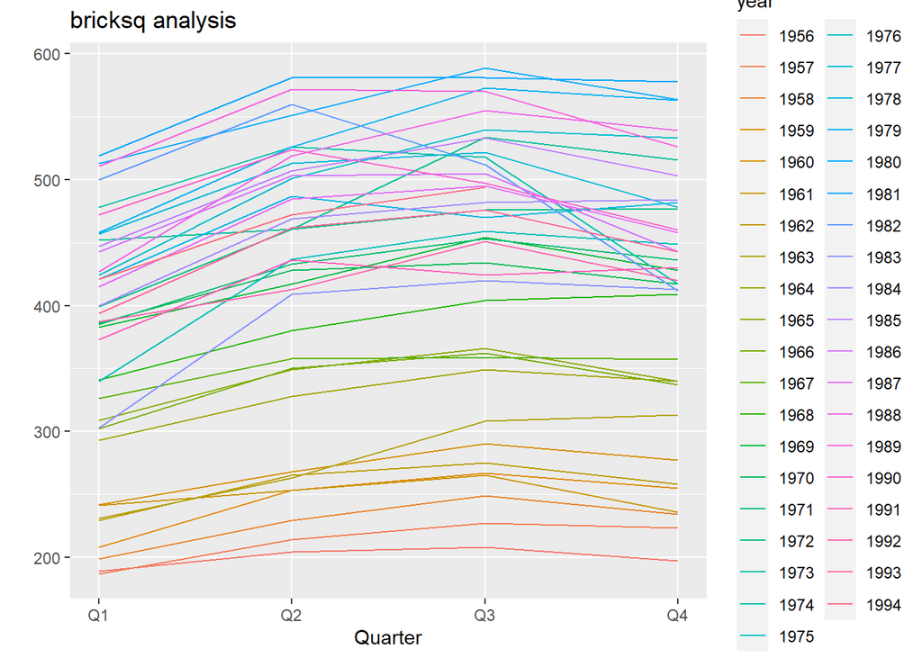

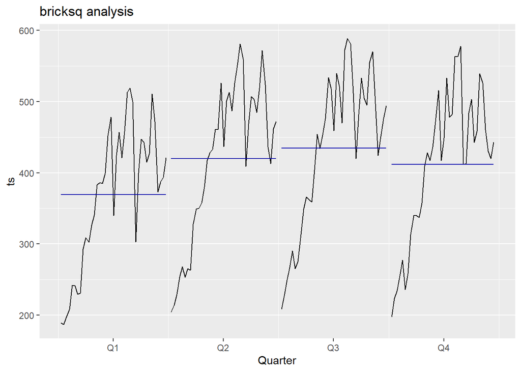

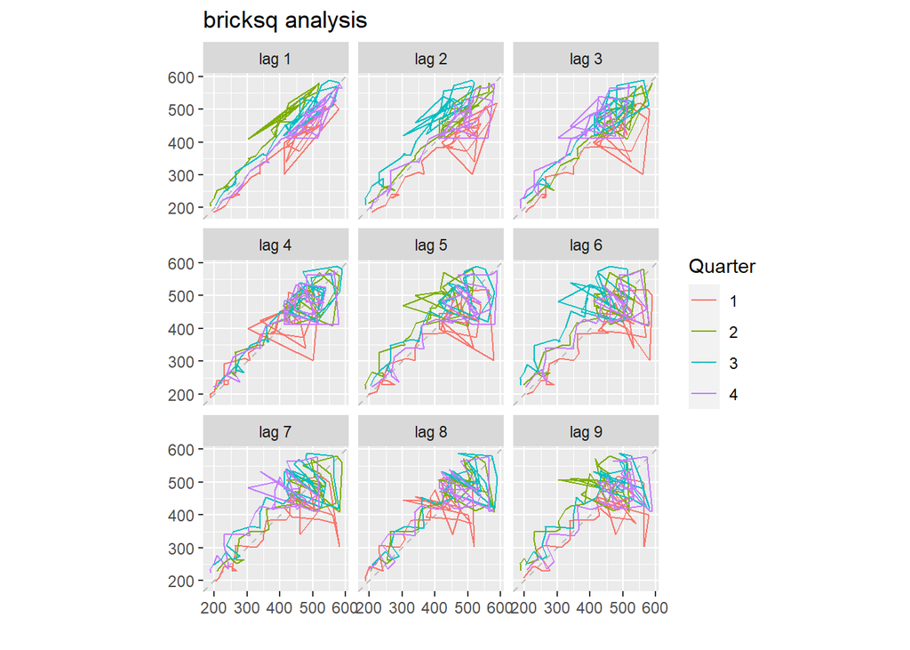

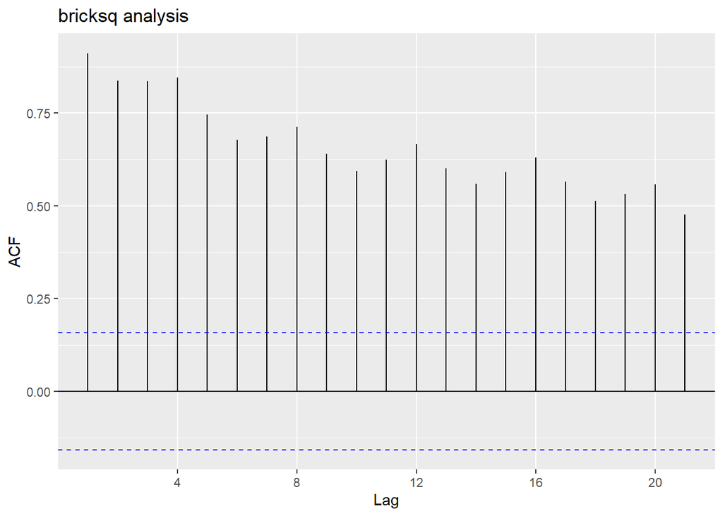

```r
analyzets(bricksq, 'bricksq analysis')
```

**This series shows positive trend till 70’s. There is a seasonal pattern here. We can see a swing quarter to quarter where it peaks in Q2 and Q3 while it dips in Q1 and Q4. Subseries plot also have similar pattern.**

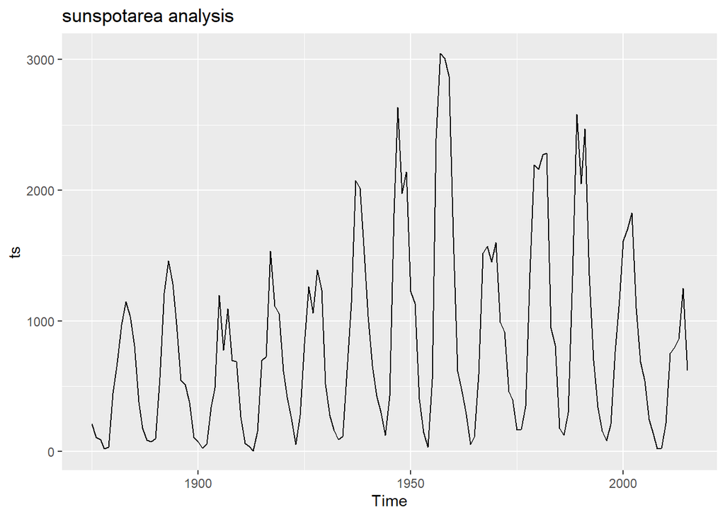

```
## Error in ggseasonplot(ts) : Data are not seasonal
## Error in ggsubseriesplot(ts) : Data are not seasonal
```

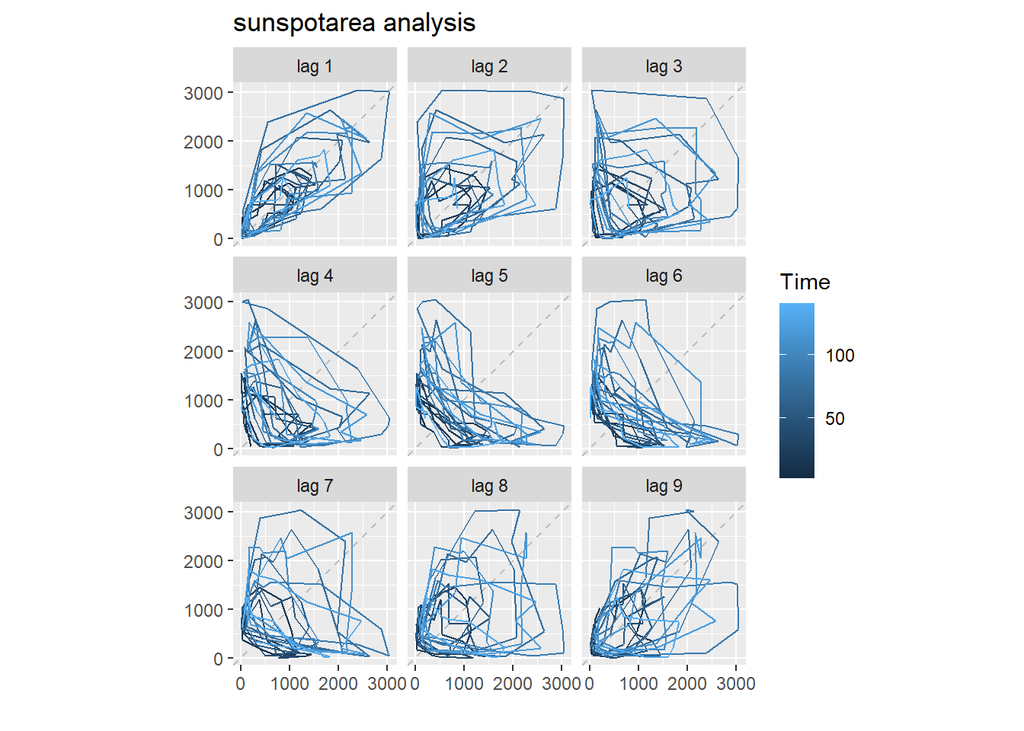

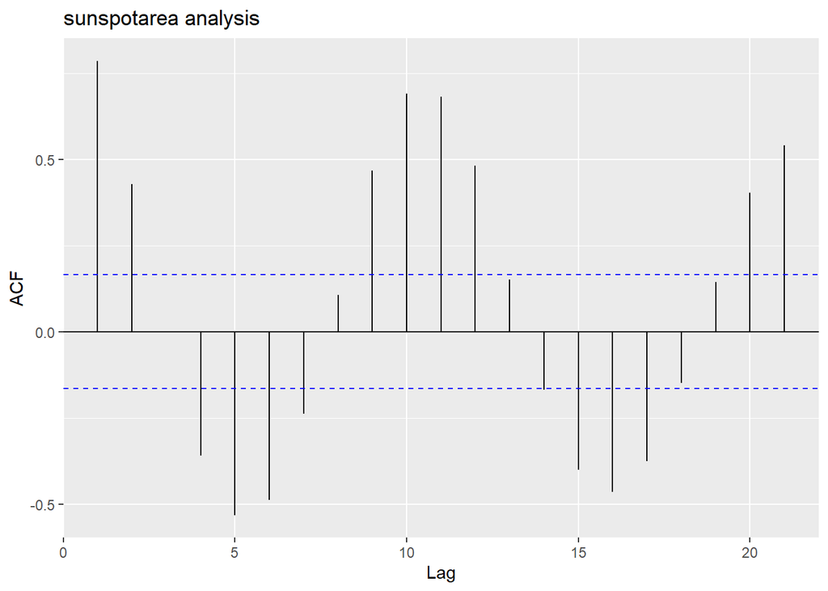

```r
analyzets(sunspotarea, 'sunspotarea analysis')
```

**sunspotarea analysis shows both positive and negative correlation i.e lag 1 and 2 shows positive coorelation while lag 5 and 6 shows negative**